```python
import pandas as pd
import numpy as np
import requests
import time
import matplotlib.pyplot as plt
%matplotlib inline
%config InlineBackend.figure_format = 'retina'
import seaborn as sns
import tweepy
from tweepy import OAuthHandler
import json
from timeit import default_timer as timer
```

# Gather

## Twitter archive

```python
#read csv file
df1= pd.read_csv('twitter-archive-enhanced.csv')
```

## Image Predictions

```python
#use request to download tsv file from a website
url ='https://d17h27t6h515a5.cloudfront.net/topher/2017/August/599fd2ad_image-predictions/image-predictions.tsv'
response = requests.get(url)

with open (url.split('/')[-1], mode = 'wb') as file:
    file.write(response.content)

#read downloaded file (tsv)

df2 = pd.read_csv('image-predictions.tsv', sep = ('\t'))
```

## API Data

```python
consumer_key = 'HIDDEN'
consumer_secret = 'HIDDEN'
access_token = 'HIDDEN'
access_secret = 'HIDDEN'

auth = OAuthHandler(consumer_key, consumer_secret)
auth.set_access_token(access_token, access_secret)

api = tweepy.API(auth, wait_on_rate_limit=True)


tweet_ids = df1.tweet_id.values
len(tweet_ids)

# Query Twitter's API for JSON data for each tweet ID in the Twitter archive
count = 0
fails_dict = {}
start = timer()
# Save each tweet's returned JSON as a new line in a .txt file
with open('tweet_json.txt', 'w') as outfile:
    # This loop will likely take 20-30 minutes to run because of Twitter's rate limit
    for tweet_id in tweet_ids:
        count += 1
        print(str(count) + ": " + str(tweet_id))
        try:
            tweet = api.get_status(tweet_id, tweet_mode='extended')
            print("Success")
            json.dump(tweet._json, outfile)
            outfile.write('\n')
        except tweepy.TweepError as e:
            print("Fail")
            fails_dict[tweet_id] = e
            pass
end = timer()
print(end - start)
print(fails_dict)

df3= pd.read_json('tweet-json.txt', lines = True)
```

[output not shown]

[output cut: 4659 more lines]

[output not shown]

# Access

```python
df1.head()
```

|  | tweet_id | in_reply_to_status_id | in_reply_to_user_id | timestamp | source | text | retweeted_status_id | retweeted_status_user_id | retweeted_status_timestamp | expanded_urls | rating_numerator | rating_denominator | name | doggo | floofer | pupper | puppo |
| --- | --- | --- | --- | --- | --- | --- | --- | --- | --- | --- | --- | --- | --- | --- | --- | --- | --- |
| 0 | 892420643555336193 | NaN | NaN | 2017-08-01 16:23:56 +0000 | <a href="http://twitter.com/download/iphone" r... | This is Phineas. He's a mystical boy. Only eve... | NaN | NaN | NaN | https://twitter.com/dog_rates/status/892420643... | 13 | 10 | Phineas | None | None | None | None |
| 1 | 892177421306343426 | NaN | NaN | 2017-08-01 00:17:27 +0000 | <a href="http://twitter.com/download/iphone" r... | This is Tilly. She's just checking pup on you.... | NaN | NaN | NaN | https://twitter.com/dog_rates/status/892177421... | 13 | 10 | Tilly | None | None | None | None |
| 2 | 891815181378084864 | NaN | NaN | 2017-07-31 00:18:03 +0000 | <a href="http://twitter.com/download/iphone" r... | This is Archie. He is a rare Norwegian Pouncin... | NaN | NaN | NaN | https://twitter.com/dog_rates/status/891815181... | 12 | 10 | Archie | None | None | None | None |
| 3 | 891689557279858688 | NaN | NaN | 2017-07-30 15:58:51 +0000 | <a href="http://twitter.com/download/iphone" r... | This is Darla. She commenced a snooze mid meal... | NaN | NaN | NaN | https://twitter.com/dog_rates/status/891689557... | 13 | 10 | Darla | None | None | None | None |
| 4 | 891327558926688256 | NaN | NaN | 2017-07-29 16:00:24 +0000 | <a href="http://twitter.com/download/iphone" r... | This is Franklin. He would like you to stop ca... | NaN | NaN | NaN | https://twitter.com/dog_rates/status/891327558... | 12 | 10 | Franklin | None | None | None | None |

```python
df1.tail()
```

|  | tweet_id | in_reply_to_status_id | in_reply_to_user_id | timestamp | source | text | retweeted_status_id | retweeted_status_user_id | retweeted_status_timestamp | expanded_urls | rating_numerator | rating_denominator | name | doggo | floofer | pupper | puppo |
| --- | --- | --- | --- | --- | --- | --- | --- | --- | --- | --- | --- | --- | --- | --- | --- | --- | --- |
| 2351 | 666049248165822465 | NaN | NaN | 2015-11-16 00:24:50 +0000 | <a href="http://twitter.com/download/iphone" r... | Here we have a 1949 1st generation vulpix. Enj... | NaN | NaN | NaN | https://twitter.com/dog_rates/status/666049248... | 5 | 10 | None | None | None | None | None |
| 2352 | 666044226329800704 | NaN | NaN | 2015-11-16 00:04:52 +0000 | <a href="http://twitter.com/download/iphone" r... | This is a purebred Piers Morgan. Loves to Netf... | NaN | NaN | NaN | https://twitter.com/dog_rates/status/666044226... | 6 | 10 | a | None | None | None | None |
| 2353 | 666033412701032449 | NaN | NaN | 2015-11-15 23:21:54 +0000 | <a href="http://twitter.com/download/iphone" r... | Here is a very happy pup. Big fan of well-main... | NaN | NaN | NaN | https://twitter.com/dog_rates/status/666033412... | 9 | 10 | a | None | None | None | None |
| 2354 | 666029285002620928 | NaN | NaN | 2015-11-15 23:05:30 +0000 | <a href="http://twitter.com/download/iphone" r... | This is a western brown Mitsubishi terrier. Up... | NaN | NaN | NaN | https://twitter.com/dog_rates/status/666029285... | 7 | 10 | a | None | None | None | None |
| 2355 | 666020888022790149 | NaN | NaN | 2015-11-15 22:32:08 +0000 | <a href="http://twitter.com/download/iphone" r... | Here we have a Japanese Irish Setter. Lost eye... | NaN | NaN | NaN | https://twitter.com/dog_rates/status/666020888... | 8 | 10 | None | None | None | None | None |

```python
df1.info()
```

```
<class 'pandas.core.frame.DataFrame'>
RangeIndex: 2356 entries, 0 to 2355
Data columns (total 17 columns):
 #   Column                      Non-Null Count  Dtype
---  ------                      --------------  -----
 0   tweet_id                    2356 non-null   int64
 1   in_reply_to_status_id       78 non-null     float64
 2   in_reply_to_user_id         78 non-null     float64
 3   timestamp                   2356 non-null   object
 4   source                      2356 non-null   object
 5   text                        2356 non-null   object
 6   retweeted_status_id         181 non-null    float64
 7   retweeted_status_user_id    181 non-null    float64
 8   retweeted_status_timestamp  181 non-null    object
 9   expanded_urls               2297 non-null   object
 10  rating_numerator            2356 non-null   int64
 11  rating_denominator          2356 non-null   int64
 12  name                        2356 non-null   object
 13  doggo                       2356 non-null   object
 14  floofer                     2356 non-null   object
 15  pupper                      2356 non-null   object
 16  puppo                       2356 non-null   object
dtypes: float64(4), int64(3), object(10)
memory usage: 313.0+ KB
```

```python
df1['rating_numerator'].sort_values()
```

```
315        0
1016       0
2335       1
2261       1
2338       1
        ...
2074     420
188      420
189      666
313      960
979     1776
Name: rating_numerator, Length: 2356, dtype: int64
```

```python
df1['rating_denominator'].sort_values()
```

```
313       0
2335      2
516       7
1576     10
1575     10
       ...
1635    110
1779    120
1634    130
902     150
1120    170
Name: rating_denominator, Length: 2356, dtype: int64
```

```python
df1.describe()
```

|  | tweet_id | in_reply_to_status_id | in_reply_to_user_id | retweeted_status_id | retweeted_status_user_id | rating_numerator | rating_denominator |
| --- | --- | --- | --- | --- | --- | --- | --- |
| count | 2.356000e+03 | 7.800000e+01 | 7.800000e+01 | 1.810000e+02 | 1.810000e+02 | 2356.000000 | 2356.000000 |
| mean | 7.427716e+17 | 7.455079e+17 | 2.014171e+16 | 7.720400e+17 | 1.241698e+16 | 13.126486 | 10.455433 |
| std | 6.856705e+16 | 7.582492e+16 | 1.252797e+17 | 6.236928e+16 | 9.599254e+16 | 45.876648 | 6.745237 |
| min | 6.660209e+17 | 6.658147e+17 | 1.185634e+07 | 6.661041e+17 | 7.832140e+05 | 0.000000 | 0.000000 |
| 25% | 6.783989e+17 | 6.757419e+17 | 3.086374e+08 | 7.186315e+17 | 4.196984e+09 | 10.000000 | 10.000000 |
| 50% | 7.196279e+17 | 7.038708e+17 | 4.196984e+09 | 7.804657e+17 | 4.196984e+09 | 11.000000 | 10.000000 |
| 75% | 7.993373e+17 | 8.257804e+17 | 4.196984e+09 | 8.203146e+17 | 4.196984e+09 | 12.000000 | 10.000000 |
| max | 8.924206e+17 | 8.862664e+17 | 8.405479e+17 | 8.874740e+17 | 7.874618e+17 | 1776.000000 | 170.000000 |

```python
df1.duplicated().sum()
```

```
0
```

```python
df1.isnull().sum()
```

```
tweet_id                         0
in_reply_to_status_id         2278
in_reply_to_user_id           2278
timestamp                        0
source                           0
text                             0
retweeted_status_id           2175
retweeted_status_user_id      2175
retweeted_status_timestamp    2175
expanded_urls                   59
rating_numerator                 0
rating_denominator               0
name                             0
doggo                            0
floofer                          0
pupper                           0
puppo                            0
dtype: int64
```

```python
df1.name.value_counts()
```

```
None        745
a            55
Charlie      12
Oliver       11
Cooper       11
           ...
Mookie        1
Asher         1
Bert          1
Snickers      1
Norman        1
Name: name, Length: 957, dtype: int64
```

```python
df1.query('expanded_urls == "None" | tweet_id  == "None" | in_reply_to_status_id == "None"| in_reply_to_user_id == "None" | timestamp == "None" | source == "None" | text == "None" | retweeted_status_id == "None" | retweeted_status_user_id == "None" | retweeted_status_timestamp == "None"| expanded_urls  == "None"|rating_numerator == "None"|rating_denominator == "None"')
```

|  | tweet_id | in_reply_to_status_id | in_reply_to_user_id | timestamp | source | text | retweeted_status_id | retweeted_status_user_id | retweeted_status_timestamp | expanded_urls | rating_numerator | rating_denominator | name | doggo | floofer | pupper | puppo |
| --- | --- | --- | --- | --- | --- | --- | --- | --- | --- | --- | --- | --- | --- | --- | --- | --- | --- |

```python
df2.head()
```

|  | tweet_id | jpg_url | img_num | p1 | p1_conf | p1_dog | p2 | p2_conf | p2_dog | p3 | p3_conf | p3_dog |
| --- | --- | --- | --- | --- | --- | --- | --- | --- | --- | --- | --- | --- |
| 0 | 666020888022790149 | https://pbs.twimg.com/media/CT4udn0WwAA0aMy.jpg | 1 | Welsh_springer_spaniel | 0.465074 | True | collie | 0.156665 | True | Shetland_sheepdog | 0.061428 | True |
| 1 | 666029285002620928 | https://pbs.twimg.com/media/CT42GRgUYAA5iDo.jpg | 1 | redbone | 0.506826 | True | miniature_pinscher | 0.074192 | True | Rhodesian_ridgeback | 0.072010 | True |
| 2 | 666033412701032449 | https://pbs.twimg.com/media/CT4521TWwAEvMyu.jpg | 1 | German_shepherd | 0.596461 | True | malinois | 0.138584 | True | bloodhound | 0.116197 | True |
| 3 | 666044226329800704 | https://pbs.twimg.com/media/CT5Dr8HUEAA-lEu.jpg | 1 | Rhodesian_ridgeback | 0.408143 | True | redbone | 0.360687 | True | miniature_pinscher | 0.222752 | True |
| 4 | 666049248165822465 | https://pbs.twimg.com/media/CT5IQmsXIAAKY4A.jpg | 1 | miniature_pinscher | 0.560311 | True | Rottweiler | 0.243682 | True | Doberman | 0.154629 | True |

```python
df2.tail()
```

|  | tweet_id | jpg_url | img_num | p1 | p1_conf | p1_dog | p2 | p2_conf | p2_dog | p3 | p3_conf | p3_dog |
| --- | --- | --- | --- | --- | --- | --- | --- | --- | --- | --- | --- | --- |
| 2070 | 891327558926688256 | https://pbs.twimg.com/media/DF6hr6BUMAAzZgT.jpg | 2 | basset | 0.555712 | True | English_springer | 0.225770 | True | German_short-haired_pointer | 0.175219 | True |
| 2071 | 891689557279858688 | https://pbs.twimg.com/media/DF_q7IAWsAEuuN8.jpg | 1 | paper_towel | 0.170278 | False | Labrador_retriever | 0.168086 | True | spatula | 0.040836 | False |
| 2072 | 891815181378084864 | https://pbs.twimg.com/media/DGBdLU1WsAANxJ9.jpg | 1 | Chihuahua | 0.716012 | True | malamute | 0.078253 | True | kelpie | 0.031379 | True |
| 2073 | 892177421306343426 | https://pbs.twimg.com/media/DGGmoV4XsAAUL6n.jpg | 1 | Chihuahua | 0.323581 | True | Pekinese | 0.090647 | True | papillon | 0.068957 | True |
| 2074 | 892420643555336193 | https://pbs.twimg.com/media/DGKD1-bXoAAIAUK.jpg | 1 | orange | 0.097049 | False | bagel | 0.085851 | False | banana | 0.076110 | False |

```python
df2.info()
```

```
<class 'pandas.core.frame.DataFrame'>
RangeIndex: 2075 entries, 0 to 2074
Data columns (total 12 columns):
 #   Column    Non-Null Count  Dtype
---  ------    --------------  -----
 0   tweet_id  2075 non-null   int64
 1   jpg_url   2075 non-null   object
 2   img_num   2075 non-null   int64
 3   p1        2075 non-null   object
 4   p1_conf   2075 non-null   float64
 5   p1_dog    2075 non-null   bool
 6   p2        2075 non-null   object
 7   p2_conf   2075 non-null   float64
 8   p2_dog    2075 non-null   bool
 9   p3        2075 non-null   object
 10  p3_conf   2075 non-null   float64
 11  p3_dog    2075 non-null   bool
dtypes: bool(3), float64(3), int64(2), object(4)
memory usage: 152.1+ KB
```

```python
df2.img_num.value_counts()
```

```
1    1780
2     198
3      66
4      31
Name: img_num, dtype: int64
```

```python
df2.duplicated().sum()
```

```
0
```

```python
df2.groupby(['tweet_id'])['jpg_url'].value_counts()
```

```
tweet_id            jpg_url
666020888022790149  https://pbs.twimg.com/media/CT4udn0WwAA0aMy.jpg    1
666029285002620928  https://pbs.twimg.com/media/CT42GRgUYAA5iDo.jpg    1
666033412701032449  https://pbs.twimg.com/media/CT4521TWwAEvMyu.jpg    1
666044226329800704  https://pbs.twimg.com/media/CT5Dr8HUEAA-lEu.jpg    1
666049248165822465  https://pbs.twimg.com/media/CT5IQmsXIAAKY4A.jpg    1
                                                                      ..
891327558926688256  https://pbs.twimg.com/media/DF6hr6BUMAAzZgT.jpg    1
891689557279858688  https://pbs.twimg.com/media/DF_q7IAWsAEuuN8.jpg    1
891815181378084864  https://pbs.twimg.com/media/DGBdLU1WsAANxJ9.jpg    1
892177421306343426  https://pbs.twimg.com/media/DGGmoV4XsAAUL6n.jpg    1
892420643555336193  https://pbs.twimg.com/media/DGKD1-bXoAAIAUK.jpg    1
Name: jpg_url, Length: 2075, dtype: int64
```

```python
df3.head()
```

|  | created_at | id | id_str | full_text | truncated | display_text_range | entities | extended_entities | source | in_reply_to_status_id | ... | favorite_count | favorited | retweeted | possibly_sensitive | possibly_sensitive_appealable | lang | retweeted_status | quoted_status_id | quoted_status_id_str | quoted_status |
| --- | --- | --- | --- | --- | --- | --- | --- | --- | --- | --- | --- | --- | --- | --- | --- | --- | --- | --- | --- | --- | --- |
| 0 | 2017-08-01 16:23:56+00:00 | 892420643555336193 | 892420643555336192 | This is Phineas. He's a mystical boy. Only eve... | False | [0, 85] | {'hashtags': [], 'symbols': [], 'user_mentions... | {'media': [{'id': 892420639486877696, 'id_str'... | <a href="http://twitter.com/download/iphone" r... | NaN | ... | 39467 | False | False | 0.0 | 0.0 | en | NaN | NaN | NaN | NaN |
| 1 | 2017-08-01 00:17:27+00:00 | 892177421306343426 | 892177421306343424 | This is Tilly. She's just checking pup on you.... | False | [0, 138] | {'hashtags': [], 'symbols': [], 'user_mentions... | {'media': [{'id': 892177413194625024, 'id_str'... | <a href="http://twitter.com/download/iphone" r... | NaN | ... | 33819 | False | False | 0.0 | 0.0 | en | NaN | NaN | NaN | NaN |
| 2 | 2017-07-31 00:18:03+00:00 | 891815181378084864 | 891815181378084864 | This is Archie. He is a rare Norwegian Pouncin... | False | [0, 121] | {'hashtags': [], 'symbols': [], 'user_mentions... | {'media': [{'id': 891815175371796480, 'id_str'... | <a href="http://twitter.com/download/iphone" r... | NaN | ... | 25461 | False | False | 0.0 | 0.0 | en | NaN | NaN | NaN | NaN |
| 3 | 2017-07-30 15:58:51+00:00 | 891689557279858688 | 891689557279858688 | This is Darla. She commenced a snooze mid meal... | False | [0, 79] | {'hashtags': [], 'symbols': [], 'user_mentions... | {'media': [{'id': 891689552724799489, 'id_str'... | <a href="http://twitter.com/download/iphone" r... | NaN | ... | 42908 | False | False | 0.0 | 0.0 | en | NaN | NaN | NaN | NaN |
| 4 | 2017-07-29 16:00:24+00:00 | 891327558926688256 | 891327558926688256 | This is Franklin. He would like you to stop ca... | False | [0, 138] | {'hashtags': [{'text': 'BarkWeek', 'indices': ... | {'media': [{'id': 891327551943041024, 'id_str'... | <a href="http://twitter.com/download/iphone" r... | NaN | ... | 41048 | False | False | 0.0 | 0.0 | en | NaN | NaN | NaN | NaN |

5 rows × 31 columns

```python
df3.info()
```

```
<class 'pandas.core.frame.DataFrame'>
RangeIndex: 2354 entries, 0 to 2353
Data columns (total 31 columns):
 #   Column                         Non-Null Count  Dtype
---  ------                         --------------  -----
 0   created_at                     2354 non-null   datetime64[ns, UTC]
 1   id                             2354 non-null   int64
 2   id_str                         2354 non-null   int64
 3   full_text                      2354 non-null   object
 4   truncated                      2354 non-null   bool
 5   display_text_range             2354 non-null   object
 6   entities                       2354 non-null   object
 7   extended_entities              2073 non-null   object
 8   source                         2354 non-null   object
 9   in_reply_to_status_id          78 non-null     float64
```

[output cut: 23 more lines]

```python
df3.describe()
```

|  | id | id_str | in_reply_to_status_id | in_reply_to_status_id_str | in_reply_to_user_id | in_reply_to_user_id_str | geo | coordinates | contributors | retweet_count | favorite_count | possibly_sensitive | possibly_sensitive_appealable | quoted_status_id | quoted_status_id_str |
| --- | --- | --- | --- | --- | --- | --- | --- | --- | --- | --- | --- | --- | --- | --- | --- |
| count | 2.354000e+03 | 2.354000e+03 | 7.800000e+01 | 7.800000e+01 | 7.800000e+01 | 7.800000e+01 | 0.0 | 0.0 | 0.0 | 2354.000000 | 2354.000000 | 2211.0 | 2211.0 | 2.900000e+01 | 2.900000e+01 |
| mean | 7.426978e+17 | 7.426978e+17 | 7.455079e+17 | 7.455079e+17 | 2.014171e+16 | 2.014171e+16 | NaN | NaN | NaN | 3164.797366 | 8080.968564 | 0.0 | 0.0 | 8.162686e+17 | 8.162686e+17 |
| std | 6.852812e+16 | 6.852812e+16 | 7.582492e+16 | 7.582492e+16 | 1.252797e+17 | 1.252797e+17 | NaN | NaN | NaN | 5284.770364 | 11814.771334 | 0.0 | 0.0 | 6.164161e+16 | 6.164161e+16 |
| min | 6.660209e+17 | 6.660209e+17 | 6.658147e+17 | 6.658147e+17 | 1.185634e+07 | 1.185634e+07 | NaN | NaN | NaN | 0.000000 | 0.000000 | 0.0 | 0.0 | 6.721083e+17 | 6.721083e+17 |
| 25% | 6.783975e+17 | 6.783975e+17 | 6.757419e+17 | 6.757419e+17 | 3.086374e+08 | 3.086374e+08 | NaN | NaN | NaN | 624.500000 | 1415.000000 | 0.0 | 0.0 | 7.888183e+17 | 7.888183e+17 |
| 50% | 7.194596e+17 | 7.194596e+17 | 7.038708e+17 | 7.038708e+17 | 4.196984e+09 | 4.196984e+09 | NaN | NaN | NaN | 1473.500000 | 3603.500000 | 0.0 | 0.0 | 8.340867e+17 | 8.340867e+17 |
| 75% | 7.993058e+17 | 7.993058e+17 | 8.257804e+17 | 8.257804e+17 | 4.196984e+09 | 4.196984e+09 | NaN | NaN | NaN | 3652.000000 | 10122.250000 | 0.0 | 0.0 | 8.664587e+17 | 8.664587e+17 |
| max | 8.924206e+17 | 8.924206e+17 | 8.862664e+17 | 8.862664e+17 | 8.405479e+17 | 8.405479e+17 | NaN | NaN | NaN | 79515.000000 | 132810.000000 | 0.0 | 0.0 | 8.860534e+17 | 8.860534e+17 |

### Quality

#### df1

- tweet-id should be in str
- Timestamp in str format, should be in datetime.
- Erroneous datatypes (in_reply_to_status_id, in_reply_to_user_id, retweeted_status_id, retweeted_status_user_id ), should be in int instead of float, or maybe in str because we dont need to calculate anything with these collumns.
- rating_nominator and rating_denominator may have incorrect values.
- Name collumn has invalid values such as None, a.

#### df2

- tweet-id should be in str

#### df3

- All id collumns should be in str

### Tidiness

#### df1

- 4 types of dogs (doggo,floofer,pupper,puppo) can be in the same collumn.
- Some non-nessessary collumns can be deleted.

#### df2

- Some non-nessessary collumns can be deleted.
- Merge into one dataset.

#### df3

- Some non-nessessary collumns can be deleted.
- Merge into one dataset.

# Cleaning

## Tidiness

```python
#make copies of each dataframe to clean
df1_clean= df1.copy()
df2_clean= df2.copy()
df3_clean= df3.copy()
```

```python
#first we need to merge 3 data into one dataframe
#change collumn id in df3_clean into tweet_id
df3_clean.rename(columns = {'id':'tweet_id'}, inplace = True)
```

```python
#drop all unnessessary columns in df3_clean, only get 3 columns in df3_clean
df3_clean= df3_clean[['tweet_id', 'retweet_count','favorite_count']]
df3_clean.head()
```

|  | tweet_id | retweet_count | favorite_count |
| --- | --- | --- | --- |
| 0 | 892420643555336193 | 8853 | 39467 |
| 1 | 892177421306343426 | 6514 | 33819 |
| 2 | 891815181378084864 | 4328 | 25461 |
| 3 | 891689557279858688 | 8964 | 42908 |
| 4 | 891327558926688256 | 9774 | 41048 |

```python
#merge 3 data tables into one
df_master= pd.merge(df1_clean, df2_clean, how = 'inner', on = ['tweet_id'] )
df_master= pd.merge(df_master, df3_clean, how = 'inner', on = ['tweet_id'] )
df_master
```

|  | tweet_id | in_reply_to_status_id | in_reply_to_user_id | timestamp | source | text | retweeted_status_id | retweeted_status_user_id | retweeted_status_timestamp | expanded_urls | ... | p1_conf | p1_dog | p2 | p2_conf | p2_dog | p3 | p3_conf | p3_dog | retweet_count | favorite_count |
| --- | --- | --- | --- | --- | --- | --- | --- | --- | --- | --- | --- | --- | --- | --- | --- | --- | --- | --- | --- | --- | --- |
| 0 | 892420643555336193 | NaN | NaN | 2017-08-01 16:23:56 +0000 | <a href="http://twitter.com/download/iphone" r... | This is Phineas. He's a mystical boy. Only eve... | NaN | NaN | NaN | https://twitter.com/dog_rates/status/892420643... | ... | 0.097049 | False | bagel | 0.085851 | False | banana | 0.076110 | False | 8853 | 39467 |
| 1 | 892177421306343426 | NaN | NaN | 2017-08-01 00:17:27 +0000 | <a href="http://twitter.com/download/iphone" r... | This is Tilly. She's just checking pup on you.... | NaN | NaN | NaN | https://twitter.com/dog_rates/status/892177421... | ... | 0.323581 | True | Pekinese | 0.090647 | True | papillon | 0.068957 | True | 6514 | 33819 |
| 2 | 891815181378084864 | NaN | NaN | 2017-07-31 00:18:03 +0000 | <a href="http://twitter.com/download/iphone" r... | This is Archie. He is a rare Norwegian Pouncin... | NaN | NaN | NaN | https://twitter.com/dog_rates/status/891815181... | ... | 0.716012 | True | malamute | 0.078253 | True | kelpie | 0.031379 | True | 4328 | 25461 |
| 3 | 891689557279858688 | NaN | NaN | 2017-07-30 15:58:51 +0000 | <a href="http://twitter.com/download/iphone" r... | This is Darla. She commenced a snooze mid meal... | NaN | NaN | NaN | https://twitter.com/dog_rates/status/891689557... | ... | 0.170278 | False | Labrador_retriever | 0.168086 | True | spatula | 0.040836 | False | 8964 | 42908 |
| 4 | 891327558926688256 | NaN | NaN | 2017-07-29 16:00:24 +0000 | <a href="http://twitter.com/download/iphone" r... | This is Franklin. He would like you to stop ca... | NaN | NaN | NaN | https://twitter.com/dog_rates/status/891327558... | ... | 0.555712 | True | English_springer | 0.225770 | True | German_short-haired_pointer | 0.175219 | True | 9774 | 41048 |
| ... | ... | ... | ... | ... | ... | ... | ... | ... | ... | ... | ... | ... | ... | ... | ... | ... | ... | ... | ... | ... | ... |
| 2068 | 666049248165822465 | NaN | NaN | 2015-11-16 00:24:50 +0000 | <a href="http://twitter.com/download/iphone" r... | Here we have a 1949 1st generation vulpix. Enj... | NaN | NaN | NaN | https://twitter.com/dog_rates/status/666049248... | ... | 0.560311 | True | Rottweiler | 0.243682 | True | Doberman | 0.154629 | True | 41 | 111 |
| 2069 | 666044226329800704 | NaN | NaN | 2015-11-16 00:04:52 +0000 | <a href="http://twitter.com/download/iphone" r... | This is a purebred Piers Morgan. Loves to Netf... | NaN | NaN | NaN | https://twitter.com/dog_rates/status/666044226... | ... | 0.408143 | True | redbone | 0.360687 | True | miniature_pinscher | 0.222752 | True | 147 | 311 |
| 2070 | 666033412701032449 | NaN | NaN | 2015-11-15 23:21:54 +0000 | <a href="http://twitter.com/download/iphone" r... | Here is a very happy pup. Big fan of well-main... | NaN | NaN | NaN | https://twitter.com/dog_rates/status/666033412... | ... | 0.596461 | True | malinois | 0.138584 | True | bloodhound | 0.116197 | True | 47 | 128 |
| 2071 | 666029285002620928 | NaN | NaN | 2015-11-15 23:05:30 +0000 | <a href="http://twitter.com/download/iphone" r... | This is a western brown Mitsubishi terrier. Up... | NaN | NaN | NaN | https://twitter.com/dog_rates/status/666029285... | ... | 0.506826 | True | miniature_pinscher | 0.074192 | True | Rhodesian_ridgeback | 0.072010 | True | 48 | 132 |
| 2072 | 666020888022790149 | NaN | NaN | 2015-11-15 22:32:08 +0000 | <a href="http://twitter.com/download/iphone" r... | Here we have a Japanese Irish Setter. Lost eye... | NaN | NaN | NaN | https://twitter.com/dog_rates/status/666020888... | ... | 0.465074 | True | collie | 0.156665 | True | Shetland_sheepdog | 0.061428 | True | 532 | 2535 |

2073 rows × 30 columns

#### Define

Drop retweeted

#### Code

```python
df_master = df_master[df_master['retweeted_status_id'].isnull()]
df_master
```

|  | tweet_id | in_reply_to_status_id | in_reply_to_user_id | timestamp | source | text | retweeted_status_id | retweeted_status_user_id | retweeted_status_timestamp | expanded_urls | ... | p1_conf | p1_dog | p2 | p2_conf | p2_dog | p3 | p3_conf | p3_dog | retweet_count | favorite_count |
| --- | --- | --- | --- | --- | --- | --- | --- | --- | --- | --- | --- | --- | --- | --- | --- | --- | --- | --- | --- | --- | --- |
| 0 | 892420643555336193 | NaN | NaN | 2017-08-01 16:23:56 +0000 | <a href="http://twitter.com/download/iphone" r... | This is Phineas. He's a mystical boy. Only eve... | NaN | NaN | NaN | https://twitter.com/dog_rates/status/892420643... | ... | 0.097049 | False | bagel | 0.085851 | False | banana | 0.076110 | False | 8853 | 39467 |
| 1 | 892177421306343426 | NaN | NaN | 2017-08-01 00:17:27 +0000 | <a href="http://twitter.com/download/iphone" r... | This is Tilly. She's just checking pup on you.... | NaN | NaN | NaN | https://twitter.com/dog_rates/status/892177421... | ... | 0.323581 | True | Pekinese | 0.090647 | True | papillon | 0.068957 | True | 6514 | 33819 |
| 2 | 891815181378084864 | NaN | NaN | 2017-07-31 00:18:03 +0000 | <a href="http://twitter.com/download/iphone" r... | This is Archie. He is a rare Norwegian Pouncin... | NaN | NaN | NaN | https://twitter.com/dog_rates/status/891815181... | ... | 0.716012 | True | malamute | 0.078253 | True | kelpie | 0.031379 | True | 4328 | 25461 |
| 3 | 891689557279858688 | NaN | NaN | 2017-07-30 15:58:51 +0000 | <a href="http://twitter.com/download/iphone" r... | This is Darla. She commenced a snooze mid meal... | NaN | NaN | NaN | https://twitter.com/dog_rates/status/891689557... | ... | 0.170278 | False | Labrador_retriever | 0.168086 | True | spatula | 0.040836 | False | 8964 | 42908 |
| 4 | 891327558926688256 | NaN | NaN | 2017-07-29 16:00:24 +0000 | <a href="http://twitter.com/download/iphone" r... | This is Franklin. He would like you to stop ca... | NaN | NaN | NaN | https://twitter.com/dog_rates/status/891327558... | ... | 0.555712 | True | English_springer | 0.225770 | True | German_short-haired_pointer | 0.175219 | True | 9774 | 41048 |
| ... | ... | ... | ... | ... | ... | ... | ... | ... | ... | ... | ... | ... | ... | ... | ... | ... | ... | ... | ... | ... | ... |
| 2068 | 666049248165822465 | NaN | NaN | 2015-11-16 00:24:50 +0000 | <a href="http://twitter.com/download/iphone" r... | Here we have a 1949 1st generation vulpix. Enj... | NaN | NaN | NaN | https://twitter.com/dog_rates/status/666049248... | ... | 0.560311 | True | Rottweiler | 0.243682 | True | Doberman | 0.154629 | True | 41 | 111 |
| 2069 | 666044226329800704 | NaN | NaN | 2015-11-16 00:04:52 +0000 | <a href="http://twitter.com/download/iphone" r... | This is a purebred Piers Morgan. Loves to Netf... | NaN | NaN | NaN | https://twitter.com/dog_rates/status/666044226... | ... | 0.408143 | True | redbone | 0.360687 | True | miniature_pinscher | 0.222752 | True | 147 | 311 |
| 2070 | 666033412701032449 | NaN | NaN | 2015-11-15 23:21:54 +0000 | <a href="http://twitter.com/download/iphone" r... | Here is a very happy pup. Big fan of well-main... | NaN | NaN | NaN | https://twitter.com/dog_rates/status/666033412... | ... | 0.596461 | True | malinois | 0.138584 | True | bloodhound | 0.116197 | True | 47 | 128 |
| 2071 | 666029285002620928 | NaN | NaN | 2015-11-15 23:05:30 +0000 | <a href="http://twitter.com/download/iphone" r... | This is a western brown Mitsubishi terrier. Up... | NaN | NaN | NaN | https://twitter.com/dog_rates/status/666029285... | ... | 0.506826 | True | miniature_pinscher | 0.074192 | True | Rhodesian_ridgeback | 0.072010 | True | 48 | 132 |
| 2072 | 666020888022790149 | NaN | NaN | 2015-11-15 22:32:08 +0000 | <a href="http://twitter.com/download/iphone" r... | Here we have a Japanese Irish Setter. Lost eye... | NaN | NaN | NaN | https://twitter.com/dog_rates/status/666020888... | ... | 0.465074 | True | collie | 0.156665 | True | Shetland_sheepdog | 0.061428 | True | 532 | 2535 |

1994 rows × 30 columns

#### Check

```python
df_master.info()
```

```
<class 'pandas.core.frame.DataFrame'>
Int64Index: 1994 entries, 0 to 2072
Data columns (total 30 columns):
 #   Column                      Non-Null Count  Dtype
---  ------                      --------------  -----
 0   tweet_id                    1994 non-null   int64
 1   in_reply_to_status_id       23 non-null     float64
 2   in_reply_to_user_id         23 non-null     float64
 3   timestamp                   1994 non-null   object
 4   source                      1994 non-null   object
 5   text                        1994 non-null   object
 6   retweeted_status_id         0 non-null      float64
 7   retweeted_status_user_id    0 non-null      float64
 8   retweeted_status_timestamp  0 non-null      object
 9   expanded_urls               1994 non-null   object
```

[output cut: 22 more lines]

#### Define

Remove retweeted columns

#### Code

```python
df_master= df_master.drop('retweeted_status_id', axis =1)
df_master= df_master.drop('retweeted_status_user_id', axis =1)
df_master= df_master.drop('retweeted_status_timestamp', axis =1)
```

#### Check

```python
df_master.shape
```

```
(1994, 27)
```

#### Define

Combine 4 dog types into one column

#### Code

```python
dog = ['doggo', 'floofer', 'pupper', 'puppo']
list1= list(df_master.columns)
list2 = []
for x in list1:
    if x in dog:
        continue
    list2.append(x)
print(list2)
print(dog)
```

```
['tweet_id', 'in_reply_to_status_id', 'in_reply_to_user_id', 'timestamp', 'source', 'text', 'expanded_urls', 'rating_numerator', 'rating_denominator', 'name', 'jpg_url', 'img_num', 'p1', 'p1_conf', 'p1_dog', 'p2', 'p2_conf', 'p2_dog', 'p3', 'p3_conf', 'p3_dog', 'retweet_count', 'favorite_count']
['doggo', 'floofer', 'pupper', 'puppo']
```

```python
# make 4 dog_types column become one column
df_master = df_master.melt(id_vars = list2, value_vars = dog, var_name = 'types', value_name = 'dog_type')
df_master
```

|  | tweet_id | in_reply_to_status_id | in_reply_to_user_id | timestamp | source | text | expanded_urls | rating_numerator | rating_denominator | name | ... | p2 | p2_conf | p2_dog | p3 | p3_conf | p3_dog | retweet_count | favorite_count | types | dog_type |
| --- | --- | --- | --- | --- | --- | --- | --- | --- | --- | --- | --- | --- | --- | --- | --- | --- | --- | --- | --- | --- | --- |
| 0 | 892420643555336193 | NaN | NaN | 2017-08-01 16:23:56 +0000 | <a href="http://twitter.com/download/iphone" r... | This is Phineas. He's a mystical boy. Only eve... | https://twitter.com/dog_rates/status/892420643... | 13 | 10 | Phineas | ... | bagel | 0.085851 | False | banana | 0.076110 | False | 8853 | 39467 | doggo | None |
| 1 | 892177421306343426 | NaN | NaN | 2017-08-01 00:17:27 +0000 | <a href="http://twitter.com/download/iphone" r... | This is Tilly. She's just checking pup on you.... | https://twitter.com/dog_rates/status/892177421... | 13 | 10 | Tilly | ... | Pekinese | 0.090647 | True | papillon | 0.068957 | True | 6514 | 33819 | doggo | None |
| 2 | 891815181378084864 | NaN | NaN | 2017-07-31 00:18:03 +0000 | <a href="http://twitter.com/download/iphone" r... | This is Archie. He is a rare Norwegian Pouncin... | https://twitter.com/dog_rates/status/891815181... | 12 | 10 | Archie | ... | malamute | 0.078253 | True | kelpie | 0.031379 | True | 4328 | 25461 | doggo | None |
| 3 | 891689557279858688 | NaN | NaN | 2017-07-30 15:58:51 +0000 | <a href="http://twitter.com/download/iphone" r... | This is Darla. She commenced a snooze mid meal... | https://twitter.com/dog_rates/status/891689557... | 13 | 10 | Darla | ... | Labrador_retriever | 0.168086 | True | spatula | 0.040836 | False | 8964 | 42908 | doggo | None |
| 4 | 891327558926688256 | NaN | NaN | 2017-07-29 16:00:24 +0000 | <a href="http://twitter.com/download/iphone" r... | This is Franklin. He would like you to stop ca... | https://twitter.com/dog_rates/status/891327558... | 12 | 10 | Franklin | ... | English_springer | 0.225770 | True | German_short-haired_pointer | 0.175219 | True | 9774 | 41048 | doggo | None |
| ... | ... | ... | ... | ... | ... | ... | ... | ... | ... | ... | ... | ... | ... | ... | ... | ... | ... | ... | ... | ... | ... |
| 7971 | 666049248165822465 | NaN | NaN | 2015-11-16 00:24:50 +0000 | <a href="http://twitter.com/download/iphone" r... | Here we have a 1949 1st generation vulpix. Enj... | https://twitter.com/dog_rates/status/666049248... | 5 | 10 | None | ... | Rottweiler | 0.243682 | True | Doberman | 0.154629 | True | 41 | 111 | puppo | None |
| 7972 | 666044226329800704 | NaN | NaN | 2015-11-16 00:04:52 +0000 | <a href="http://twitter.com/download/iphone" r... | This is a purebred Piers Morgan. Loves to Netf... | https://twitter.com/dog_rates/status/666044226... | 6 | 10 | a | ... | redbone | 0.360687 | True | miniature_pinscher | 0.222752 | True | 147 | 311 | puppo | None |
| 7973 | 666033412701032449 | NaN | NaN | 2015-11-15 23:21:54 +0000 | <a href="http://twitter.com/download/iphone" r... | Here is a very happy pup. Big fan of well-main... | https://twitter.com/dog_rates/status/666033412... | 9 | 10 | a | ... | malinois | 0.138584 | True | bloodhound | 0.116197 | True | 47 | 128 | puppo | None |
| 7974 | 666029285002620928 | NaN | NaN | 2015-11-15 23:05:30 +0000 | <a href="http://twitter.com/download/iphone" r... | This is a western brown Mitsubishi terrier. Up... | https://twitter.com/dog_rates/status/666029285... | 7 | 10 | a | ... | miniature_pinscher | 0.074192 | True | Rhodesian_ridgeback | 0.072010 | True | 48 | 132 | puppo | None |
| 7975 | 666020888022790149 | NaN | NaN | 2015-11-15 22:32:08 +0000 | <a href="http://twitter.com/download/iphone" r... | Here we have a Japanese Irish Setter. Lost eye... | https://twitter.com/dog_rates/status/666020888... | 8 | 10 | None | ... | collie | 0.156665 | True | Shetland_sheepdog | 0.061428 | True | 532 | 2535 | puppo | None |

7976 rows × 25 columns

```python
#drop column types name
df_master = df_master.drop('types', 1)
```

```python
# check that column types name is dropped
df_master.shape
```

```
(7976, 24)
```

```python
df_master
```

|  | tweet_id | in_reply_to_status_id | in_reply_to_user_id | timestamp | source | text | expanded_urls | rating_numerator | rating_denominator | name | ... | p1_dog | p2 | p2_conf | p2_dog | p3 | p3_conf | p3_dog | retweet_count | favorite_count | dog_type |
| --- | --- | --- | --- | --- | --- | --- | --- | --- | --- | --- | --- | --- | --- | --- | --- | --- | --- | --- | --- | --- | --- |
| 0 | 892420643555336193 | NaN | NaN | 2017-08-01 16:23:56 +0000 | <a href="http://twitter.com/download/iphone" r... | This is Phineas. He's a mystical boy. Only eve... | https://twitter.com/dog_rates/status/892420643... | 13 | 10 | Phineas | ... | False | bagel | 0.085851 | False | banana | 0.076110 | False | 8853 | 39467 | None |
| 1 | 892177421306343426 | NaN | NaN | 2017-08-01 00:17:27 +0000 | <a href="http://twitter.com/download/iphone" r... | This is Tilly. She's just checking pup on you.... | https://twitter.com/dog_rates/status/892177421... | 13 | 10 | Tilly | ... | True | Pekinese | 0.090647 | True | papillon | 0.068957 | True | 6514 | 33819 | None |
| 2 | 891815181378084864 | NaN | NaN | 2017-07-31 00:18:03 +0000 | <a href="http://twitter.com/download/iphone" r... | This is Archie. He is a rare Norwegian Pouncin... | https://twitter.com/dog_rates/status/891815181... | 12 | 10 | Archie | ... | True | malamute | 0.078253 | True | kelpie | 0.031379 | True | 4328 | 25461 | None |
| 3 | 891689557279858688 | NaN | NaN | 2017-07-30 15:58:51 +0000 | <a href="http://twitter.com/download/iphone" r... | This is Darla. She commenced a snooze mid meal... | https://twitter.com/dog_rates/status/891689557... | 13 | 10 | Darla | ... | False | Labrador_retriever | 0.168086 | True | spatula | 0.040836 | False | 8964 | 42908 | None |
| 4 | 891327558926688256 | NaN | NaN | 2017-07-29 16:00:24 +0000 | <a href="http://twitter.com/download/iphone" r... | This is Franklin. He would like you to stop ca... | https://twitter.com/dog_rates/status/891327558... | 12 | 10 | Franklin | ... | True | English_springer | 0.225770 | True | German_short-haired_pointer | 0.175219 | True | 9774 | 41048 | None |
| ... | ... | ... | ... | ... | ... | ... | ... | ... | ... | ... | ... | ... | ... | ... | ... | ... | ... | ... | ... | ... | ... |
| 7971 | 666049248165822465 | NaN | NaN | 2015-11-16 00:24:50 +0000 | <a href="http://twitter.com/download/iphone" r... | Here we have a 1949 1st generation vulpix. Enj... | https://twitter.com/dog_rates/status/666049248... | 5 | 10 | None | ... | True | Rottweiler | 0.243682 | True | Doberman | 0.154629 | True | 41 | 111 | None |
| 7972 | 666044226329800704 | NaN | NaN | 2015-11-16 00:04:52 +0000 | <a href="http://twitter.com/download/iphone" r... | This is a purebred Piers Morgan. Loves to Netf... | https://twitter.com/dog_rates/status/666044226... | 6 | 10 | a | ... | True | redbone | 0.360687 | True | miniature_pinscher | 0.222752 | True | 147 | 311 | None |
| 7973 | 666033412701032449 | NaN | NaN | 2015-11-15 23:21:54 +0000 | <a href="http://twitter.com/download/iphone" r... | Here is a very happy pup. Big fan of well-main... | https://twitter.com/dog_rates/status/666033412... | 9 | 10 | a | ... | True | malinois | 0.138584 | True | bloodhound | 0.116197 | True | 47 | 128 | None |
| 7974 | 666029285002620928 | NaN | NaN | 2015-11-15 23:05:30 +0000 | <a href="http://twitter.com/download/iphone" r... | This is a western brown Mitsubishi terrier. Up... | https://twitter.com/dog_rates/status/666029285... | 7 | 10 | a | ... | True | miniature_pinscher | 0.074192 | True | Rhodesian_ridgeback | 0.072010 | True | 48 | 132 | None |
| 7975 | 666020888022790149 | NaN | NaN | 2015-11-15 22:32:08 +0000 | <a href="http://twitter.com/download/iphone" r... | Here we have a Japanese Irish Setter. Lost eye... | https://twitter.com/dog_rates/status/666020888... | 8 | 10 | None | ... | True | collie | 0.156665 | True | Shetland_sheepdog | 0.061428 | True | 532 | 2535 | None |

7976 rows × 24 columns

```python
df_master.dog_type.value_counts()
```

```
None       7659
pupper      212
doggo        74
puppo        23
floofer       8
Name: dog_type, dtype: int64
```

```python
df_master.groupby(df_master['tweet_id'])['dog_type'].value_counts().sort_values()
```

```
tweet_id            dog_type
673707060090052608  pupper      1
817777686764523521  doggo       1
                    pupper      1
756526248105566208  doggo       1
701545186879471618  pupper      1
                               ..
687807801670897665  None        4
687664829264453632  None        4
687494652870668288  None        4
688908934925697024  None        4
892420643555336193  None        4
Name: dog_type, Length: 2311, dtype: int64
```

```python
#sort dog_type in order
df_master = df_master.sort_values('dog_type')
df_master
```

|  | tweet_id | in_reply_to_status_id | in_reply_to_user_id | timestamp | source | text | expanded_urls | rating_numerator | rating_denominator | name | ... | p1_dog | p2 | p2_conf | p2_dog | p3 | p3_conf | p3_dog | retweet_count | favorite_count | dog_type |
| --- | --- | --- | --- | --- | --- | --- | --- | --- | --- | --- | --- | --- | --- | --- | --- | --- | --- | --- | --- | --- | --- |
| 0 | 892420643555336193 | NaN | NaN | 2017-08-01 16:23:56 +0000 | <a href="http://twitter.com/download/iphone" r... | This is Phineas. He's a mystical boy. Only eve... | https://twitter.com/dog_rates/status/892420643... | 13 | 10 | Phineas | ... | False | bagel | 0.085851 | False | banana | 0.076110 | False | 8853 | 39467 | None |
| 5315 | 683030066213818368 | NaN | NaN | 2016-01-01 21:00:32 +0000 | <a href="http://twitter.com/download/iphone" r... | This is Lulu. She's contemplating all her unre... | https://twitter.com/dog_rates/status/683030066... | 10 | 10 | Lulu | ... | True | bull_mastiff | 0.193804 | True | French_bulldog | 0.055194 | True | 832 | 2370 | None |
| 5313 | 683098815881154561 | NaN | NaN | 2016-01-02 01:33:43 +0000 | <a href="http://twitter.com/download/iphone" r... | aahhhhkslaldhwnxmzbbs 12/10 for being da smoos... | https://twitter.com/dog_rates/status/683098815... | 12 | 10 | None | ... | True | kuvasz | 0.053008 | True | Labrador_retriever | 0.037881 | True | 736 | 2361 | None |
| 5310 | 683357973142474752 | NaN | NaN | 2016-01-02 18:43:31 +0000 | <a href="http://twitter.com/download/iphone" r... | "Have a seat, son. There are some things we ne... | https://twitter.com/dog_rates/status/683357973... | 10 | 10 | None | ... | True | Cardigan | 0.154854 | True | Siberian_husky | 0.136366 | True | 1059 | 3238 | None |
| 5309 | 683391852557561860 | NaN | NaN | 2016-01-02 20:58:09 +0000 | <a href="http://twitter.com/download/iphone" r... | Say hello to Jack (pronounced "Kevin"). He's a... | https://twitter.com/dog_rates/status/683391852... | 11 | 10 | Jack | ... | True | Boston_bull | 0.004749 | True | pug | 0.001392 | True | 2702 | 8356 | None |
| ... | ... | ... | ... | ... | ... | ... | ... | ... | ... | ... | ... | ... | ... | ... | ... | ... | ... | ... | ... | ... | ... |
| 6463 | 790946055508652032 | NaN | NaN | 2016-10-25 16:00:09 +0000 | <a href="http://twitter.com/download/iphone" r... | This is Betty. She's assisting with the dishes... | https://twitter.com/dog_rates/status/790946055... | 12 | 10 | Betty | ... | False | golden_retriever | 0.245773 | True | chow | 0.039012 | True | 5496 | 18601 | puppo |
| 6087 | 867421006826221569 | NaN | NaN | 2017-05-24 16:44:18 +0000 | <a href="http://twitter.com/download/iphone" r... | This is Shikha. She just watched you drop a sk... | https://twitter.com/dog_rates/status/867421006... | 12 | 10 | Shikha | ... | True | Siberian_husky | 0.381330 | True | malamute | 0.001670 | True | 2697 | 16755 | puppo |
| 6044 | 878776093423087618 | NaN | NaN | 2017-06-25 00:45:22 +0000 | <a href="http://twitter.com/download/iphone" r... | This is Snoopy. He's a proud #PrideMonthPuppo.... | https://twitter.com/dog_rates/status/878776093... | 13 | 10 | Snoopy | ... | True | whippet | 0.150487 | True | Ibizan_hound | 0.039725 | True | 4319 | 19763 | puppo |
| 6279 | 825535076884762624 | NaN | NaN | 2017-01-29 02:44:34 +0000 | <a href="http://twitter.com/download/iphone" r... | Here's a very loving and accepting puppo. Appe... | https://twitter.com/dog_rates/status/825535076... | 14 | 10 | None | ... | True | Tibetan_mastiff | 0.147940 | True | black-and-tan_coonhound | 0.024525 | True | 19669 | 56413 | puppo |
| 6764 | 743253157753532416 | NaN | NaN | 2016-06-16 01:25:36 +0000 | <a href="http://twitter.com/download/iphone" r... | This is Kilo. He cannot reach the snackum. Nif... | https://twitter.com/dog_rates/status/743253157... | 10 | 10 | Kilo | ... | True | Siberian_husky | 0.368137 | True | Eskimo_dog | 0.177822 | True | 1366 | 4624 | puppo |

7976 rows × 24 columns

```python
#keep only one tweet_id for dog_type and we get the last one.
df_master = df_master.sort_values('dog_type').drop_duplicates('tweet_id', keep = 'last')
df_master
```

|  | tweet_id | in_reply_to_status_id | in_reply_to_user_id | timestamp | source | text | expanded_urls | rating_numerator | rating_denominator | name | ... | p1_dog | p2 | p2_conf | p2_dog | p3 | p3_conf | p3_dog | retweet_count | favorite_count | dog_type |
| --- | --- | --- | --- | --- | --- | --- | --- | --- | --- | --- | --- | --- | --- | --- | --- | --- | --- | --- | --- | --- | --- |
| 4655 | 757725642876129280 | NaN | NaN | 2016-07-25 23:54:05 +0000 | <a href="http://twitter.com/download/iphone" r... | This is Beckham. He fell asleep at the wheel. ... | https://twitter.com/dog_rates/status/757725642... | 11 | 10 | Beckham | ... | False | Labrador_retriever | 0.128128 | True | Siamese_cat | 0.091241 | False | 1391 | 5022 | None |
| 4705 | 750117059602808832 | NaN | NaN | 2016-07-05 00:00:18 +0000 | <a href="http://twitter.com/download/iphone" r... | This is Calvin. He just loves America so much.... | https://twitter.com/dog_rates/status/750117059... | 10 | 10 | Calvin | ... | True | Lhasa | 0.175220 | True | Pekinese | 0.008072 | True | 1466 | 4740 | None |
| 4706 | 750101899009982464 | NaN | NaN | 2016-07-04 23:00:03 +0000 | <a href="http://twitter.com/download/iphone" r... | Meet Lilah. She agreed on one quick pic. Now s... | https://twitter.com/dog_rates/status/750101899... | 11 | 10 | Lilah | ... | True | llama | 0.174269 | False | Labrador_retriever | 0.147364 | True | 959 | 3344 | None |
| 4654 | 757741869644341248 | NaN | NaN | 2016-07-26 00:58:34 +0000 | <a href="http://twitter.com/download/iphone" r... | This is Leonard. He hides in bushes to escape ... | https://twitter.com/dog_rates/status/757741869... | 10 | 10 | Leonard | ... | False | Old_English_sheepdog | 0.128899 | True | Siberian_husky | 0.019076 | True | 3710 | 7613 | None |
| 4651 | 758405701903519748 | NaN | NaN | 2016-07-27 20:56:24 +0000 | <a href="http://twitter.com/download/iphone" r... | This is Odie. He falls asleep wherever he want... | https://twitter.com/dog_rates/status/758405701... | 10 | 10 | Odie | ... | True | laptop | 0.092277 | False | notebook | 0.032727 | False | 2204 | 5756 | None |
| ... | ... | ... | ... | ... | ... | ... | ... | ... | ... | ... | ... | ... | ... | ... | ... | ... | ... | ... | ... | ... | ... |
| 5996 | 889531135344209921 | NaN | NaN | 2017-07-24 17:02:04 +0000 | <a href="http://twitter.com/download/iphone" r... | This is Stuart. He's sporting his favorite fan... | https://twitter.com/dog_rates/status/889531135... | 13 | 10 | Stuart | ... | True | Labrador_retriever | 0.013834 | True | redbone | 0.007958 | True | 2321 | 15359 | puppo |
| 6281 | 825026590719483904 | NaN | NaN | 2017-01-27 17:04:02 +0000 | <a href="http://twitter.com/download/iphone" r... | Say hello to Pablo. He's one gorgeous puppo. A... | https://www.gofundme.com/my-puppys-double-cata... | 12 | 10 | Pablo | ... | True | Siberian_husky | 0.467678 | True | malamute | 0.004976 | True | 1483 | 7020 | puppo |
| 6279 | 825535076884762624 | NaN | NaN | 2017-01-29 02:44:34 +0000 | <a href="http://twitter.com/download/iphone" r... | Here's a very loving and accepting puppo. Appe... | https://twitter.com/dog_rates/status/825535076... | 14 | 10 | None | ... | True | Tibetan_mastiff | 0.147940 | True | black-and-tan_coonhound | 0.024525 | True | 19669 | 56413 | puppo |
| 6481 | 787717603741622272 | NaN | NaN | 2016-10-16 18:11:26 +0000 | <a href="http://twitter.com/download/iphone" r... | This is Tonks. She is a service puppo. Can hea... | https://twitter.com/dog_rates/status/787717603... | 13 | 10 | Tonks | ... | True | malinois | 0.004920 | True | kelpie | 0.000853 | True | 3240 | 11416 | puppo |
| 6764 | 743253157753532416 | NaN | NaN | 2016-06-16 01:25:36 +0000 | <a href="http://twitter.com/download/iphone" r... | This is Kilo. He cannot reach the snackum. Nif... | https://twitter.com/dog_rates/status/743253157... | 10 | 10 | Kilo | ... | True | Siberian_husky | 0.368137 | True | Eskimo_dog | 0.177822 | True | 1366 | 4624 | puppo |

1994 rows × 24 columns

#### Check

```python
df_master.shape
```

```
(1994, 24)
```

#### Define

Delete unnecessary columns

#### Code

```python
df_master.columns
```

```
Index(['tweet_id', 'in_reply_to_status_id', 'in_reply_to_user_id', 'timestamp',
       'source', 'text', 'expanded_urls', 'rating_numerator',
       'rating_denominator', 'name', 'jpg_url', 'img_num', 'p1', 'p1_conf',
       'p1_dog', 'p2', 'p2_conf', 'p2_dog', 'p3', 'p3_conf', 'p3_dog',
       'retweet_count', 'favorite_count', 'dog_type'],
      dtype='object')
```

```python
df_master= df_master.drop('img_num', axis =1)
df_master= df_master.drop('p1', axis =1)
df_master= df_master.drop('p1_conf', axis =1)
df_master= df_master.drop('p1_dog', axis =1)
df_master= df_master.drop('p2', axis =1)
df_master= df_master.drop('p2_conf', axis =1)
df_master= df_master.drop('p2_dog', axis =1)
df_master= df_master.drop('p3', axis =1)
df_master= df_master.drop('p3_conf', axis =1)
df_master= df_master.drop('p3_dog', axis =1)
```

#### Check

```python
df_master.columns
```

```
Index(['tweet_id', 'in_reply_to_status_id', 'in_reply_to_user_id', 'timestamp',
       'source', 'text', 'expanded_urls', 'rating_numerator',
       'rating_denominator', 'name', 'jpg_url', 'retweet_count',
       'favorite_count', 'dog_type'],
      dtype='object')
```

## Quality

```python
df_master.head(1)
```

|  | tweet_id | in_reply_to_status_id | in_reply_to_user_id | timestamp | source | text | expanded_urls | rating_numerator | rating_denominator | name | jpg_url | retweet_count | favorite_count | dog_type |
| --- | --- | --- | --- | --- | --- | --- | --- | --- | --- | --- | --- | --- | --- | --- |
| 4655 | 757725642876129280 | NaN | NaN | 2016-07-25 23:54:05 +0000 | <a href="http://twitter.com/download/iphone" r... | This is Beckham. He fell asleep at the wheel. ... | https://twitter.com/dog_rates/status/757725642... | 11 | 10 | Beckham | https://pbs.twimg.com/media/CoP7c4bWcAAr55g.jpg | 1391 | 5022 | None |

#### Define

Change datatype of tweet_id,in_reply_to_status_id,in_reply_to_user_id , dog_type and timestamp

#### Code

```python
df_master.tweet_id = df_master.tweet_id.astype(str)
df_master.in_reply_to_status_id  = df_master.in_reply_to_status_id .astype(str)
df_master.in_reply_to_user_id= df_master.in_reply_to_user_id.astype(str)
```

```python
df_master.timestamp= pd.to_datetime(df_master.timestamp)
```

```python
df_master.dog_type=df_master.dog_type.astype('category')
```

#### Check

```python
df_master.info()
```

```
<class 'pandas.core.frame.DataFrame'>
Int64Index: 1994 entries, 4655 to 6764
Data columns (total 14 columns):
 #   Column                 Non-Null Count  Dtype
---  ------                 --------------  -----
 0   tweet_id               1994 non-null   object
 1   in_reply_to_status_id  1994 non-null   object
 2   in_reply_to_user_id    1994 non-null   object
 3   timestamp              1994 non-null   datetime64[ns, UTC]
 4   source                 1994 non-null   object
 5   text                   1994 non-null   object
 6   expanded_urls          1994 non-null   object
 7   rating_numerator       1994 non-null   int64
 8   rating_denominator     1994 non-null   int64
 9   name                   1994 non-null   object
 10  jpg_url                1994 non-null   object
 11  retweet_count          1994 non-null   int64
 12  favorite_count         1994 non-null   int64
 13  dog_type               1994 non-null   category
dtypes: category(1), datetime64[ns, UTC](1), int64(4), object(8)
memory usage: 220.2+ KB
```

#### Define

Change html source to easy text to understand

#### Code

```python
#check content of many sources
df_master.source.value_counts()
```

```
<a href="http://twitter.com/download/iphone" rel="nofollow">Twitter for iPhone</a>     1955
<a href="http://twitter.com" rel="nofollow">Twitter Web Client</a>                       28
<a href="https://about.twitter.com/products/tweetdeck" rel="nofollow">TweetDeck</a>      11
Name: source, dtype: int64
```

```python
#change html links to short texts
df_master.source= df_master.source.str.replace('<a href="http://twitter.com/download/iphone" rel="nofollow">Twitter for iPhone</a>', 'Twitter for iPhone')
df_master.source= df_master.source.str.replace('<a href="http://twitter.com" rel="nofollow">Twitter Web Client</a>', 'Twitter Web Client')
df_master.source = df_master.source.str.replace('<a href="https://about.twitter.com/products/tweetdeck" rel="nofollow">TweetDeck</a>', 'TweetDeck')
```

#### Check

```python
df_master.source.value_counts()
```

```
Twitter for iPhone    1955
Twitter Web Client      28
TweetDeck               11
Name: source, dtype: int64
```

```python
#change source type to category
df_master.source.astype('category')
```

```
4655    Twitter for iPhone
4705    Twitter for iPhone
4706    Twitter for iPhone
4654    Twitter for iPhone
4651    Twitter for iPhone
               ...
5996    Twitter for iPhone
6281    Twitter for iPhone
6279    Twitter for iPhone
6481    Twitter for iPhone
6764    Twitter for iPhone
Name: source, Length: 1994, dtype: category
Categories (3, object): ['TweetDeck', 'Twitter Web Client', 'Twitter for iPhone']
```

```python
df_master.source.value_counts()
```

```
Twitter for iPhone    1955
Twitter Web Client      28
TweetDeck               11
Name: source, dtype: int64
```

#### Define

Display full text column

#### Code

```python
pd.options.display.max_colwidth = 10000
```

#### Check

```python
df_master.head(1)
```

|  | tweet_id | in_reply_to_status_id | in_reply_to_user_id | timestamp | source | text | expanded_urls | rating_numerator | rating_denominator | name | jpg_url | retweet_count | favorite_count | dog_type |
| --- | --- | --- | --- | --- | --- | --- | --- | --- | --- | --- | --- | --- | --- | --- |
| 4655 | 757725642876129280 | nan | nan | 2016-07-25 23:54:05+00:00 | Twitter for iPhone | This is Beckham. He fell asleep at the wheel. Very churlish. Looks to have a backpup driver tho. That's good. 11/10 https://t.co/rptsOm73Wr | https://twitter.com/dog_rates/status/757725642876129280/photo/1,https://twitter.com/dog_rates/status/757725642876129280/photo/1 | 11 | 10 | Beckham | https://pbs.twimg.com/media/CoP7c4bWcAAr55g.jpg | 1391 | 5022 | None |

#### Define

Remove replies

#### Code

```python
df_master.in_reply_to_status_id.value_counts()
```

```
nan                      1971
6.671521640794235e+17       2
7.03255935813288e+17        1
6.747933991411466e+17       1
6.70668383499735e+17        1
6.715610021362811e+17       1
6.754971033223864e+17       1
6.920419346894029e+17       1
6.747522332008202e+17       1
6.749998076819087e+17       1
8.55818117272019e+17        1
6.75349384339542e+17        1
6.678064545737605e+17       1
7.468859193875743e+17       1
6.75707330206548e+17        1
7.590995235327795e+17       1
6.717299066283418e+17       1
6.844810745593815e+17       1
7.33109485275861e+17        1
7.291135312709919e+17       1
6.914168664520827e+17       1
6.842228683355054e+17       1
7.030419496500347e+17       1
Name: in_reply_to_status_id, dtype: int64
```

```python
df_master=df_master.query('in_reply_to_status_id == "nan"')
```

#### Check

```python
df_master.shape
```

```
(1971, 14)
```

```python
#drop in_reply_to_status_id and in_reply_to_user_id
df_master= df_master.drop('in_reply_to_status_id', axis =1)
```

```python
df_master = df_master.drop('in_reply_to_user_id', axis =1)
```

```python
df_master.head()
```

|  | tweet_id | timestamp | source | text | expanded_urls | rating_numerator | rating_denominator | name | jpg_url | retweet_count | favorite_count | dog_type |
| --- | --- | --- | --- | --- | --- | --- | --- | --- | --- | --- | --- | --- |
| 4655 | 757725642876129280 | 2016-07-25 23:54:05+00:00 | Twitter for iPhone | This is Beckham. He fell asleep at the wheel. Very churlish. Looks to have a backpup driver tho. That's good. 11/10 https://t.co/rptsOm73Wr | https://twitter.com/dog_rates/status/757725642876129280/photo/1,https://twitter.com/dog_rates/status/757725642876129280/photo/1 | 11 | 10 | Beckham | https://pbs.twimg.com/media/CoP7c4bWcAAr55g.jpg | 1391 | 5022 | None |
| 4705 | 750117059602808832 | 2016-07-05 00:00:18+00:00 | Twitter for iPhone | This is Calvin. He just loves America so much. 10/10 would roll around in flag with https://t.co/RXdzWaCQHm | https://twitter.com/dog_rates/status/750117059602808832/photo/1,https://twitter.com/dog_rates/status/750117059602808832/photo/1,https://twitter.com/dog_rates/status/750117059602808832/photo/1,https://… | 10 | 10 | Calvin | https://pbs.twimg.com/media/Cmjzc-oWEAESFCm.jpg | 1466 | 4740 | None |
| 4706 | 750101899009982464 | 2016-07-04 23:00:03+00:00 | Twitter for iPhone | Meet Lilah. She agreed on one quick pic. Now she'd like to go mentally prepare for the onslaught of fireworks. 11/10 https://t.co/enCpXzZHkD | https://twitter.com/dog_rates/status/750101899009982464/photo/1,https://twitter.com/dog_rates/status/750101899009982464/photo/1 | 11 | 10 | Lilah | https://pbs.twimg.com/media/Cmjlsh1XgAEvhq_.jpg | 959 | 3344 | None |
| 4654 | 757741869644341248 | 2016-07-26 00:58:34+00:00 | Twitter for iPhone | This is Leonard. He hides in bushes to escape his problems. 10/10 relatable af https://t.co/TdyGTcX0uo | https://twitter.com/dog_rates/status/757741869644341248/photo/1,https://twitter.com/dog_rates/status/757741869644341248/photo/1 | 10 | 10 | Leonard | https://pbs.twimg.com/media/CoQKNY7XYAE_cuX.jpg | 3710 | 7613 | None |
| 4651 | 758405701903519748 | 2016-07-27 20:56:24+00:00 | Twitter for iPhone | This is Odie. He falls asleep wherever he wants. Must be nice. 10/10 https://t.co/M9BXCSDVjh | https://twitter.com/dog_rates/status/758405701903519748/photo/1,https://twitter.com/dog_rates/status/758405701903519748/photo/1,https://twitter.com/dog_rates/status/758405701903519748/photo/1,https://… | 10 | 10 | Odie | https://pbs.twimg.com/media/CoZl9fXWgAMox0n.jpg | 2204 | 5756 | None |

#### Define

Remove html from text

#### Code

```python
def remove_last_line_from_text(s):
    return s[:s.find('http')]

df_master.text= df_master.text.apply(remove_last_line_from_text)
```

#### Check

```python
df_master.text.head(20)
```

```
4655     This is Beckham. He fell asleep at the wheel. Very churlish. Looks to have a backpup driver tho. That's good. 11/10
4705                                     This is Calvin. He just loves America so much. 10/10 would roll around in flag with
4706    Meet Lilah. She agreed on one quick pic. Now she'd like to go mentally prepare for the onslaught of fireworks. 11/10
4654                                          This is Leonard. He hides in bushes to escape his problems. 10/10 relatable af
4651                                                    This is Odie. He falls asleep wherever he wants. Must be nice. 10/10
4688            This is Brody. He's a lifeguard. Always prepared for rescue. 12/10 would fake drown just to get saved by him
4689                                      This is Ruby. Her ice cube is melting. She doesn't know what to do about it. 11/10
4690                                            This is Tucker. He's very camera shy. 12/10 would give stellar belly rubs to
4691                                                                   This is Toby. A cat got his tongue. 13/10 adorable af
4693                           This is Max. She has one ear that's always slightly more alert than the other. 10/10 wonky af
4695          This is Gilbert. He's being chased by a battalion of miniature floof cows. 10/10 we all believe in you Gilbert
4696               "This photographer took pics of her best friend before and after she told them they were beautiful" 12/10
4699      This is Meyer. He has to hold somebody's hand during car rides. He's also wearing a seatbelt. 12/10 responsible af
4701                                                         This is Arnie. He's a Nova Scotian Fridge Floof. Rare af. 12/10
4703                                                          And finally, happy 4th of July from the squad 🇺🇸 13/10 for all
4704                            This is Stewie. He will roundhouse kick anyone who questions his independence. 11/10 free af
4652       This is Corey. He's a Portobello Corgicool. Trying to convince you that he's not a hipster. 11/10 yea right Corey
4653    Teagan reads entire books in store so they're free. Loved 50 Shades of Grey (how dare I make that joke so late) 9/10
4645                                    This is Spencer. He's part of the Queen's Guard. Takes his job very seriously. 11/10
4648     Meet Boston. He's worried because his tongue won't fit all the way in his mouth. 12/10 it'll be ok deep breaths pup
Name: text, dtype: object
```

#### Define

Make year, month, day_of_week column

#### Code

```python
df_master['year'] = df_master['timestamp'].dt.year
df_master['month'] = df_master['timestamp'].dt.month
df_master['day_of_week']= df_master['timestamp'].dt.weekday
```

```python
df_master['month'].replace(1, 'January', inplace=True)
df_master['month'].replace(2, 'February', inplace=True)
df_master['month'].replace(3, 'March', inplace=True)
df_master['month'].replace(4, 'April', inplace=True)
df_master['month'].replace(5, 'May', inplace=True)
df_master['month'].replace(6, 'June', inplace=True)
df_master['month'].replace(7, 'July', inplace=True)
df_master['month'].replace(8, 'August', inplace=True)
df_master['month'].replace(9, 'September', inplace=True)
df_master['month'].replace(10, 'October', inplace=True)
df_master['month'].replace(11, 'November', inplace=True)
df_master['month'].replace(12, 'December', inplace=True)
```

```python
df_master['day_of_week'].replace(0, 'Monday', inplace=True)
df_master['day_of_week'].replace(1, 'Tuesday', inplace=True)
df_master['day_of_week'].replace(2, 'Wednesday', inplace=True)
df_master['day_of_week'].replace(3, 'Thursday', inplace=True)
df_master['day_of_week'].replace(4, 'Friday', inplace=True)
df_master['day_of_week'].replace(5, 'Saturday', inplace=True)
df_master['day_of_week'].replace(6, 'Sunday', inplace=True)
```

#### Check

```python
df_master.iloc[:,10:]
```

|  | favorite_count | dog_type | year | month | day_of_week |
| --- | --- | --- | --- | --- | --- |
| 4655 | 5022 | None | 2016 | July | Monday |
| 4705 | 4740 | None | 2016 | July | Tuesday |
| 4706 | 3344 | None | 2016 | July | Monday |
| 4654 | 7613 | None | 2016 | July | Tuesday |
| 4651 | 5756 | None | 2016 | July | Wednesday |
| ... | ... | ... | ... | ... | ... |
| 5996 | 15359 | puppo | 2017 | July | Monday |
| 6281 | 7020 | puppo | 2017 | January | Friday |
| 6279 | 56413 | puppo | 2017 | January | Sunday |
| 6481 | 11416 | puppo | 2016 | October | Sunday |
| 6764 | 4624 | puppo | 2016 | June | Thursday |

1971 rows × 5 columns

#### Define

Create dog name from text column and create new dog name column

#### Code

```python
def get_dog_name(x):
    return x[:x.find('.')]

text = df_master.text
dog_name = text.apply(get_dog_name)
```

```python
df_master['dog_name']= dog_name.str.rsplit(' ', 1).str[-1].str.strip('""()\' ')
```

```python
#drop old name column
df_master= df_master.drop('name', axis=1)
```

```python
dog_name =[]
for name in list(df_master['dog_name']):
    if name.istitle():
        dog_name.append(name)
    else:
        dog_name.append('None')
df_master['dog_name']= dog_name
```

#### Check

```python
df_master['dog_name'].sort_values()
```

```
6753     Abby
6742     Abby
4681      Ace
7561     Acro
5020    Adele
        ...
5990     Zoey
6075     Zoey
7767     Zoey
6103    Zooey
5513     Zuzu
Name: dog_name, Length: 1971, dtype: object
```

```python
list(dog_name)
```

```
['Beckham',
 'Calvin',
 'Lilah',
 'Leonard',
 'Odie',
 'Brody',
 'Ruby',
 'Tucker',
 'Toby',
 'Max',
 'Gilbert',
 'None',
 'Meyer',
 'Arnie',
 'None',
 'Stewie',
 'Corey',
 'None',
 'Spencer',
 'Boston',
 'Brandonald',
 'None',
 'Kevin',
 'None',
 'Charlie',
 'None',
 'None',
 'Scout',
 'Hank',
 'Ace',
 'Tayzie',
 'Grizzie',
 'Wiener',
 'None',
 'Zoey',
 'Bruno',
 'Darla',
 'None',
 'Setter',
 'Phineas',
```

[output cut: 946 more lines]

```
 'Kirk',
 'Ruffalo',
 'Archie',
 'Oliviér',
 'None',
 'Lola',
 'Kobe',
 'None',
 'None',
 'Freddery',
 'None',
 'Phil',
 'None',
 'None',
 ...]
```

#### Define

Create count_url column

#### Code

```python
count_url= df_master.expanded_urls.str.split(',').str.len()
```

```python
df_master['count_url']= count_url
```

#### Check

```python
df_master['count_url'].value_counts().sort_values()
```

```
5       8
4     105
3     110
2     282
1    1466
Name: count_url, dtype: int64
```

#### Define

Create column for dog sex: male or female

#### Code

```python
dog_sex =[]
for text in list(df_master.text):
    if 'He' in text or 'he'in text or 'his'in text or 'him' in text:
        dog_sex.append('Male')
    else:
        dog_sex.append('Female')
df_master['dog_sex']= dog_sex
```

#### Check

```python
df_master.dog_sex.value_counts()
```

```
Male      1880
Female      91
Name: dog_sex, dtype: int64
```

# Storing data

```python
df_master.to_csv('twitter_archive_master.csv', index=False)
```

# Analyzing, and Visualizing Data

```python
df_master.head(1)
```

|  | tweet_id | timestamp | source | text | expanded_urls | rating_numerator | rating_denominator | jpg_url | retweet_count | favorite_count | dog_type | year | month | day_of_week | dog_name | count_url | dog_sex |
| --- | --- | --- | --- | --- | --- | --- | --- | --- | --- | --- | --- | --- | --- | --- | --- | --- | --- |
| 4655 | 757725642876129280 | 2016-07-25 23:54:05+00:00 | Twitter for iPhone | This is Beckham. He fell asleep at the wheel. Very churlish. Looks to have a backpup driver tho. That's good. 11/10 | https://twitter.com/dog_rates/status/757725642876129280/photo/1,https://twitter.com/dog_rates/status/757725642876129280/photo/1 | 11 | 10 | https://pbs.twimg.com/media/CoP7c4bWcAAr55g.jpg | 1391 | 5022 | None | 2016 | July | Monday | Beckham | 2 | Male |

### 1. How many male and female dogs in the dataset?

```python
sex=df_master.dog_sex.value_counts()
sex
```

```
Male      1880
Female      91
Name: dog_sex, dtype: int64
```

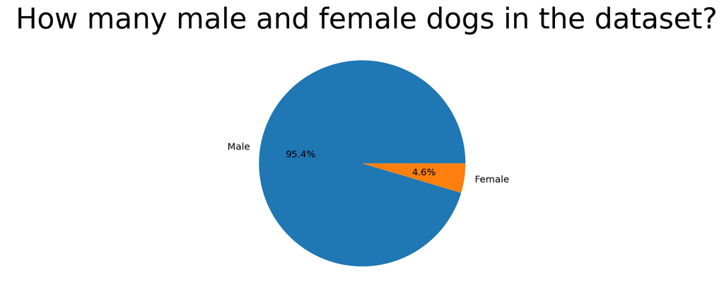

```python
plt.figure(figsize = (15,5))
plt.pie(sex ,labels = sex.index, autopct='%1.1f%%')
plt.title(' How many male and female dogs in the dataset?', fontsize=30)
```

We have 1880 male and 91 female in the dataset.

### 2. What is the most common dog names?

```python
df_master.dog_name.value_counts().head(11)
```

```
None       558
Charlie     13
Oliver      11
Cooper      10
Lucy         9
Tucker       9
Daisy        8
Penny        8
Winston      8
Lola         7
Koda         6
Name: dog_name, dtype: int64
```

Charlie is the most common name, following are Oliver and Cooper.

### 3. Which source people use most to tweet dogs?

```python
source_use =df_master.source.value_counts()
source_use
```

```
Twitter for iPhone    1932
Twitter Web Client      28
TweetDeck               11
Name: source, dtype: int64
```

```
(-1.1063671560297168,
 1.1003031985152454,
 -1.1081972428804092,
 1.10407446337736)
```

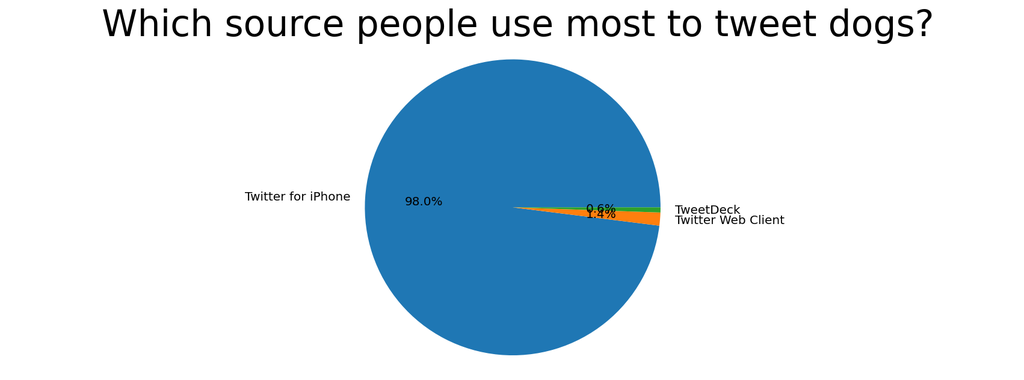

```python
plt.figure(figsize = (15,5))
plt.pie(source_use,labels = source_use.index, autopct='%1.1f%%')
plt.title(' Which source people use most to tweet dogs?', fontsize=30)
plt.axis('equal')
```

People use most Twitter for iphone to tweet dogs.

### 4. Which dog types people tweet most?

```python
a = df_master.dog_type.value_counts()
a
```

```
None       1668
pupper      209
doggo        63
puppo        23
floofer       8
Name: dog_type, dtype: int64
```

```python
b = a.iloc[1:]
b
```

```
pupper     209
doggo       63
puppo       23
floofer      8
Name: dog_type, dtype: int64
```

```python
def bar_chart(locations, heights,labels):
    plt.figure(figsize = (20,8))
    plt.bar(locations, heights, tick_label=labels)
    return plt
```

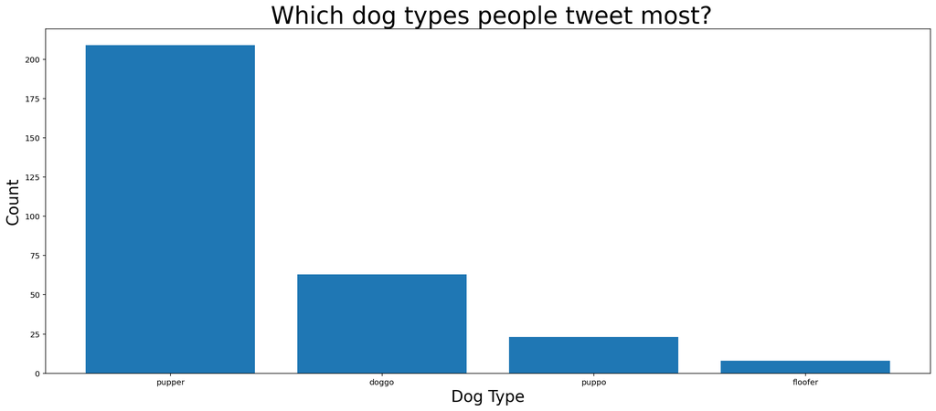

```python
bar_chart(b.index, b,b.index)
plt.title(' Which dog types people tweet most?', fontsize=30)
plt.xlabel('Dog Type', fontsize=20)
plt.ylabel('Count', fontsize=20)
```

Pupper is the type that people tweet most, following is doggo. Floofer is tweeted least.

### 5.Which day people tweet most?

```python
day_tweet_most= df_master.day_of_week.value_counts()
day_tweet_most
```

```
Monday       326
Wednesday    293
Tuesday      291
Thursday     280
Friday       279
Sunday       254
Saturday     248
Name: day_of_week, dtype: int64
```

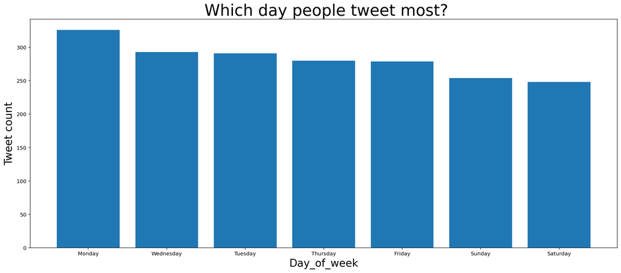

```python
bar_chart(day_tweet_most.index, day_tweet_most,day_tweet_most.index)
plt.title(' Which day people tweet most?', fontsize=30)
plt.xlabel('Day_of_week', fontsize=20)
plt.ylabel('Tweet count', fontsize=20)
```

People tweet most on Monday and least on Saturday.

### 6. Top retweeted dogs.

```python
df_master.retweet_count.nlargest(5)
```

```
775     79515
6382    56625
810     52360
6291    48265
6040    45849
Name: retweet_count, dtype: int64
```

```python
top_5= df_master.query('retweet_count == 79515 | retweet_count == 56625 | retweet_count == 52360 | retweet_count == 48265 |retweet_count == 45849').sort_values(by = 'retweet_count', ascending= False)
top_5
```

|  | tweet_id | timestamp | source | text | expanded_urls | rating_numerator | rating_denominator | jpg_url | retweet_count | favorite_count | dog_type | year | month | day_of_week | dog_name | count_url | dog_sex |
| --- | --- | --- | --- | --- | --- | --- | --- | --- | --- | --- | --- | --- | --- | --- | --- | --- | --- |
| 775 | 744234799360020481 | 2016-06-18 18:26:18+00:00 | Twitter for iPhone | Here's a doggo realizing you can stand in a pool. 13/10 enlightened af (vid by Tina Conrad) | https://twitter.com/dog_rates/status/744234799360020481/video/1 | 13 | 10 | https://pbs.twimg.com/ext_tw_video_thumb/744234667679821824/pu/img/1GaWmtJtdqzZV7jy.jpg | 79515 | 131075 | doggo | 2016 | June | Saturday | None | 1 | Male |
| 6382 | 807106840509214720 | 2016-12-09 06:17:20+00:00 | Twitter for iPhone | This is Stephan. He just wants to help. 13/10 such a good boy | https://twitter.com/dog_rates/status/807106840509214720/video/1 | 13 | 10 | https://pbs.twimg.com/ext_tw_video_thumb/807106774843039744/pu/img/8XZg1xW35Xp2J6JW.jpg | 56625 | 107015 | None | 2016 | December | Friday | Stephan | 1 | Male |
| 810 | 739238157791694849 | 2016-06-04 23:31:25+00:00 | Twitter for iPhone | Here's a doggo blowing bubbles. It's downright legendary. 13/10 would watch on repeat forever (vid by Kent Duryee) | https://twitter.com/dog_rates/status/739238157791694849/video/1 | 13 | 10 | https://pbs.twimg.com/ext_tw_video_thumb/739238016737267712/pu/img/-tLpyiuIzD5zR1et.jpg | 52360 | 75163 | doggo | 2016 | June | Saturday | None | 1 | Male |
| 6291 | 822872901745569793 | 2017-01-21 18:26:02+00:00 | Twitter for iPhone | Here's a super supportive puppo participating in the Toronto #WomensMarch today. 13/10 | https://twitter.com/dog_rates/status/822872901745569793/photo/1 | 13 | 10 | https://pbs.twimg.com/media/C2tugXLXgAArJO4.jpg | 48265 | 132810 | puppo | 2017 | January | Saturday | None | 1 | Male |
| 6040 | 879415818425184262 | 2017-06-26 19:07:24+00:00 | Twitter for iPhone | This is Duddles. He did an attempt. 13/10 someone help him (vid by Georgia Felici) | https://twitter.com/dog_rates/status/879415818425184262/video/1 | 13 | 10 | https://pbs.twimg.com/ext_tw_video_thumb/879415784908390401/pu/img/cX7XI1TnUsseGET5.jpg | 45849 | 107956 | None | 2017 | June | Monday | Duddles | 1 | Male |

```python
top_5[['dog_name', 'dog_sex', 'dog_type', 'retweet_count']]
```

|  | dog_name | dog_sex | dog_type | retweet_count |
| --- | --- | --- | --- | --- |
| 775 | None | Male | doggo | 79515 |
| 6382 | Stephan | Male | None | 56625 |
| 810 | None | Male | doggo | 52360 |
| 6291 | None | Male | puppo | 48265 |
| 6040 | Duddles | Male | None | 45849 |

```python
from IPython.display import Image
Image(url=top_5.jpg_url.iloc[0], width=300, height=300)
```

[figure not shown]

```python
Image(url=top_5.jpg_url.iloc[1], width=300, height=300)
```

[figure not shown]

```python
Image(url=top_5.jpg_url.iloc[2], width=300, height=300)
```

[figure not shown]

```python
Image(url=top_5.jpg_url.iloc[3], width=300, height=300)
```

[figure not shown]

```python
Image(url=top_5.jpg_url.iloc[4], width=300, height=300)
```

[figure not shown]

### 7. How Retweet and Favorite look like overtime ?

```python
r= df_master[['timestamp', 'retweet_count']].sort_values(by = 'timestamp')
r
```

|  | timestamp | retweet_count |
| --- | --- | --- |
| 5981 | 2015-11-15 22:32:08+00:00 | 532 |
| 5980 | 2015-11-15 23:05:30+00:00 | 48 |
| 7973 | 2015-11-15 23:21:54+00:00 | 47 |
| 7972 | 2015-11-16 00:04:52+00:00 | 147 |
| 7971 | 2015-11-16 00:24:50+00:00 | 41 |
| ... | ... | ... |
| 5986 | 2017-07-29 16:00:24+00:00 | 9774 |
| 5985 | 2017-07-30 15:58:51+00:00 | 8964 |
| 5984 | 2017-07-31 00:18:03+00:00 | 4328 |
| 5983 | 2017-08-01 00:17:27+00:00 | 6514 |
| 5982 | 2017-08-01 16:23:56+00:00 | 8853 |

1971 rows × 2 columns

```python
f=df_master[['timestamp', 'favorite_count']].sort_values(by = 'timestamp')
f
```

|  | timestamp | favorite_count |
| --- | --- | --- |
| 5981 | 2015-11-15 22:32:08+00:00 | 2535 |
| 5980 | 2015-11-15 23:05:30+00:00 | 132 |
| 7973 | 2015-11-15 23:21:54+00:00 | 128 |
| 7972 | 2015-11-16 00:04:52+00:00 | 311 |
| 7971 | 2015-11-16 00:24:50+00:00 | 111 |
| ... | ... | ... |
| 5986 | 2017-07-29 16:00:24+00:00 | 41048 |
| 5985 | 2017-07-30 15:58:51+00:00 | 42908 |
| 5984 | 2017-07-31 00:18:03+00:00 | 25461 |
| 5983 | 2017-08-01 00:17:27+00:00 | 33819 |
| 5982 | 2017-08-01 16:23:56+00:00 | 39467 |

1971 rows × 2 columns

```
(array([-20000.,      0.,  20000.,  40000.,  60000.,  80000., 100000.,
        120000., 140000.]),
 [Text(0, 0, ''),
```

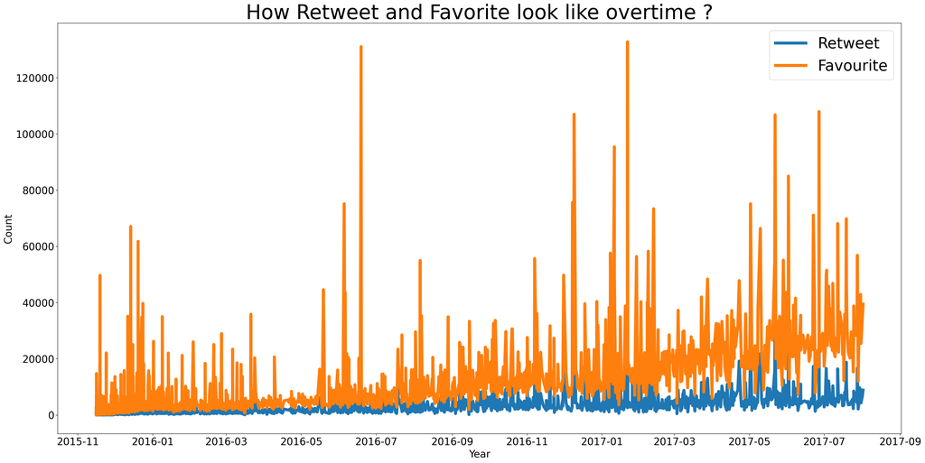

```python
plt.figure(figsize=(30,15))
plt.plot(r['timestamp'],r['retweet_count'], linewidth=6)
plt.plot(f['timestamp'],f['favorite_count'], linewidth=6)
plt.legend(["Retweet", "Favourite"], fontsize=30)
plt.title ('How Retweet and Favorite look like overtime ?', fontsize=40)
plt.xlabel ('Year', fontsize=20)
plt.ylabel ('Count', fontsize=20)
plt.xticks(fontsize=20 )
plt.yticks (fontsize=20)
```